# Alternative Fuel Stations Analysis Report

Analysis of US Alternative Fuel Infrastructure using data.gov API

by Shuhei Ando ([@ando_ds](https://x.com/ando_ds))

July 12, 2025

# Overview

This analysis report was created based on the methodology presented in the article “Using data.gov APIs in R” from the University of Virginia Library (https://library.virginia.edu/data/articles/using-data-gov-apis-in-r).

Using the data.gov API provided by the U.S. Department of Energy, we retrieve and analyze alternative fuel station data. This analysis focuses on data from five states: California, Texas, New York, Florida, and Washington, to visualize the current state and trends of alternative fuel infrastructure.

# Fuel Type Analysis

## Fuel Type Distribution

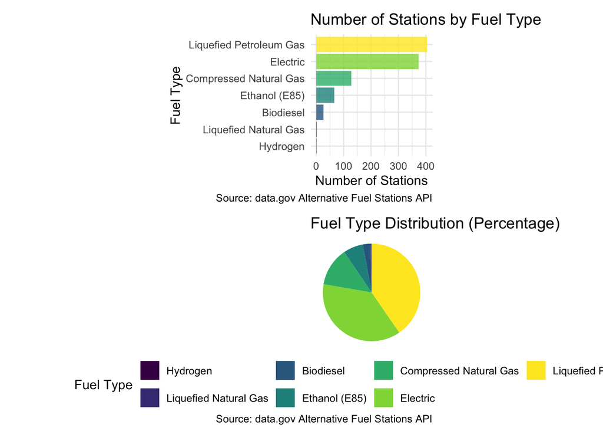

Distribution of Alternative Fuel Stations by Fuel Type

```r
# Station count by fuel type
fuel_summary <- combined_data |>
  count(fuel_type_full, sort = TRUE) |>
  mutate(
    percentage = n / sum(n) * 100,
    fuel_type_full = fct_reorder(fuel_type_full, n)
  )

# Bar chart of fuel type distribution
p1 <- fuel_summary |>
  ggplot(aes(x = fuel_type_full, y = n, fill = fuel_type_full)) +
  geom_col(alpha = 0.8) +
  coord_flip() +
  scale_fill_viridis_d(name = "Fuel Type") +
  labs(
    title = "Number of Stations by Fuel Type",
    x = "Fuel Type",
    y = "Number of Stations",
    caption = "Source: data.gov Alternative Fuel Stations API"
  ) +
  theme_minimal() +
  theme(legend.position = "none")

# Pie chart
p2 <- fuel_summary |>
  ggplot(aes(x = "", y = n, fill = fuel_type_full)) +
  geom_bar(stat = "identity", width = 1) +
  coord_polar("y", start = 0) +
  scale_fill_viridis_d(name = "Fuel Type") +
  labs(
    title = "Fuel Type Distribution (Percentage)",
    caption = "Source: data.gov Alternative Fuel Stations API"
  ) +
  theme_void() +
  theme(legend.position = "bottom")

# Combine plots
p1 / p2
```

## Fuel Type Summary Statistics

```r
# Detailed statistics table by fuel type
fuel_table <- fuel_summary |>
  select(
    `Fuel Type` = fuel_type_full,
    `Station Count` = n,
    `Percentage (%)` = percentage
  ) |>
  mutate(`Percentage (%)` = round(`Percentage (%)`, 1))

# Interactive table for HTML, static table for PDF
if (knitr::is_html_output()) {
  fuel_table |>
    DT::datatable(
      options = list(pageLength = 10, dom = 'tip'),
      caption = "Table 1: Station Count and Percentage by Fuel Type"
    )
} else {
  knitr::kable(fuel_table,
               caption = "Table 1: Station Count and Percentage by Fuel Type")
}
```

|  | Fuel Type | Station Count | Percentage (%) |
| --- | --- | --- | --- |
| 1 | Liquefied Petroleum Gas | 404 | 40.4 |
| 2 | Electric | 373 | 37.3 |
| 3 | Compressed Natural Gas | 128 | 12.8 |
| 4 | Ethanol (E85) | 66 | 6.6 |
| 5 | Biodiesel | 26 | 2.6 |
| 6 | Liquefied Natural Gas | 2 | 0.2 |
| 7 | Hydrogen | 1 | 0.1 |

# Geographic Analysis

## State-Level Distribution

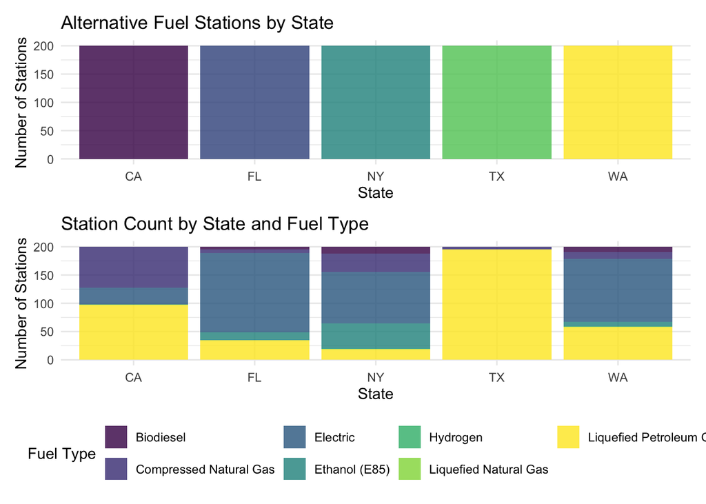

Distribution of Alternative Fuel Stations by State

```r
# State and fuel type analysis
state_fuel_summary <- combined_data |>
  count(state, fuel_type_full) |>
  group_by(state) |>
  mutate(
    state_total = sum(n),
    percentage = n / state_total * 100
  ) |>
  ungroup()

# Total stations by state
state_totals <- combined_data |>
  count(state, sort = TRUE) |>
  mutate(state = fct_reorder(state, n))

# State-level station count visualization
p3 <- state_totals |>
  ggplot(aes(x = state, y = n, fill = state)) +
  geom_col(alpha = 0.8) +
  scale_fill_viridis_d(name = "State") +
  labs(
    title = "Alternative Fuel Stations by State",
    x = "State",
    y = "Number of Stations"
  ) +
  theme_minimal() +
  theme(legend.position = "none")

# Stacked bar chart by state and fuel type
p4 <- state_fuel_summary |>
  ggplot(aes(x = state, y = n, fill = fuel_type_full)) +
  geom_col(position = "stack", alpha = 0.8) +
  scale_fill_viridis_d(name = "Fuel Type") +
  labs(
    title = "Station Count by State and Fuel Type",
    x = "State",
    y = "Number of Stations"
  ) +
  theme_minimal() +
  theme(legend.position = "bottom")

p3 / p4
```

## Geographic Distribution

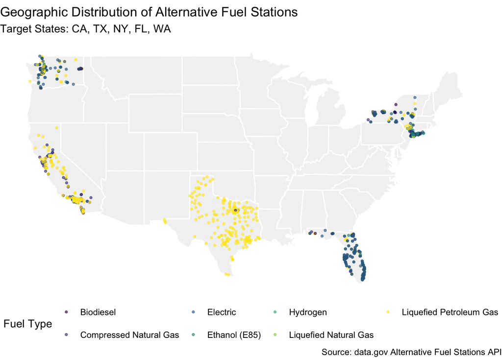

Geographic Distribution of Alternative Fuel Stations

```r
# Geographic distribution visualization
usa_map <- map_data("state")

# Plot stations on map
ggplot() +
  geom_polygon(data = usa_map, aes(x = long, y = lat, group = group),
               fill = "lightgray", color = "white", alpha = 0.3) +
  geom_point(data = combined_data,
             aes(x = longitude, y = latitude, color = fuel_type_full),
             alpha = 0.6, size = 0.8) +
  scale_color_viridis_d(name = "Fuel Type") +
  labs(
    title = "Geographic Distribution of Alternative Fuel Stations",
    subtitle = "Target States: CA, TX, NY, FL, WA",
    caption = "Source: data.gov Alternative Fuel Stations API"
  ) +
  theme_void() +
  theme(legend.position = "bottom") +
  coord_quickmap(xlim = c(-125, -65), ylim = c(25, 50))
```

# Temporal Analysis

## Installation Year Trends

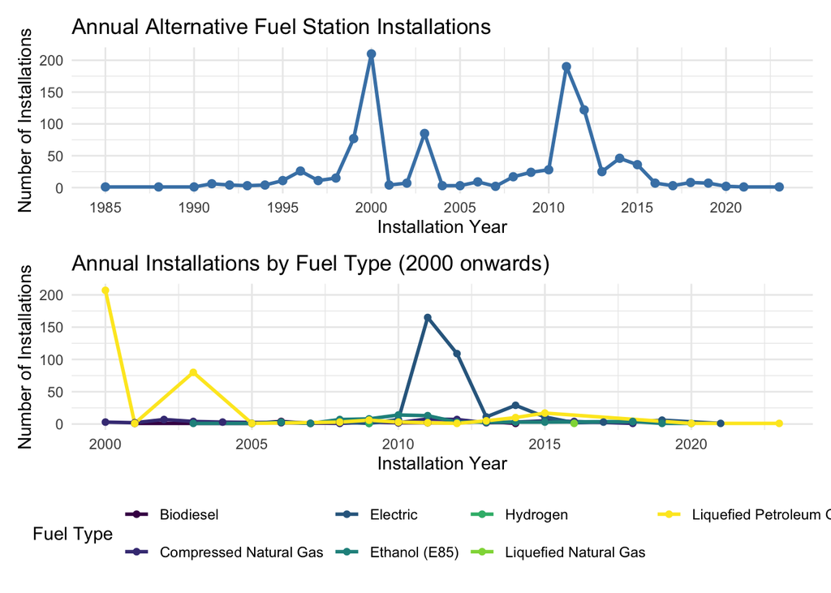

Temporal Trends in Alternative Fuel Station Installation

```r
# Yearly installation trends
yearly_trend <- combined_data |>
  filter(!is.na(open_date)) |>
  count(open_year, fuel_type_full) |>
  group_by(open_year) |>
  mutate(yearly_total = sum(n)) |>
  ungroup()

# Annual total installations
p5 <- yearly_trend |>
  group_by(open_year) |>
  summarise(total = sum(n), .groups = "drop") |>
  ggplot(aes(x = open_year, y = total)) +
  geom_line(color = "steelblue", linewidth = 1) +
  geom_point(color = "steelblue", size = 2) +
  scale_x_continuous(breaks = seq(1985, 2025, 5)) +
  labs(
    title = "Annual Alternative Fuel Station Installations",
    x = "Installation Year",
    y = "Number of Installations"
  ) +
  theme_minimal()

# Annual installations by fuel type
p6 <- yearly_trend |>
  filter(open_year >= 2000) |>  # Focus on 2000 onwards
  ggplot(aes(x = open_year, y = n, color = fuel_type_full)) +
  geom_line(linewidth = 1) +
  geom_point(size = 1.5) +
  scale_color_viridis_d(name = "Fuel Type") +
  scale_x_continuous(breaks = seq(2000, 2025, 5)) +
  labs(
    title = "Annual Installations by Fuel Type (2000 onwards)",
    x = "Installation Year",
    y = "Number of Installations"
  ) +
  theme_minimal() +
  theme(legend.position = "bottom")

p5 / p6
```

## Station Age Analysis

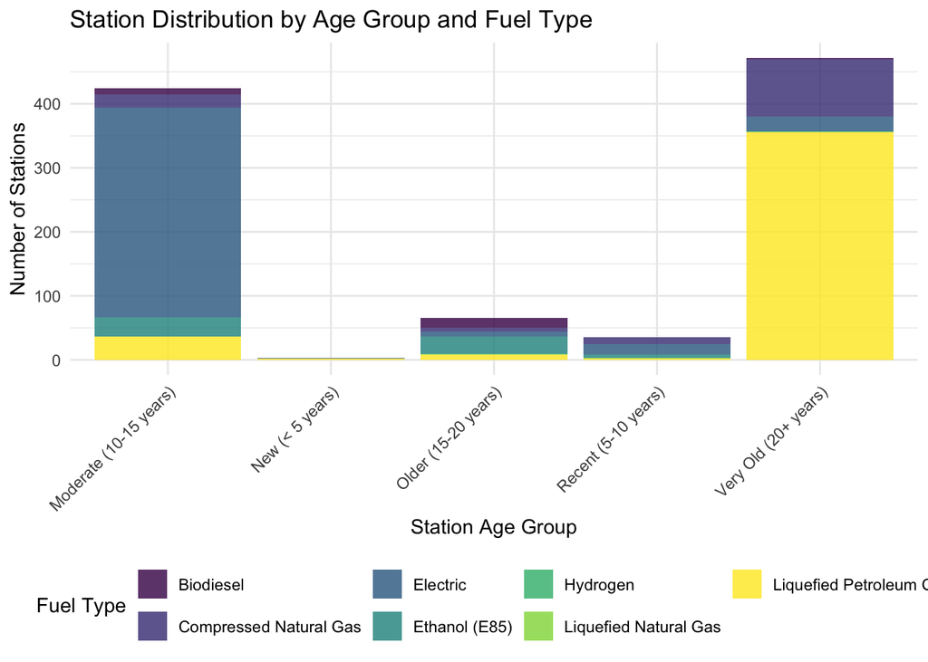

Distribution by Station Age and Fuel Type

```r
# Station age distribution
age_summary <- combined_data |>
  filter(!is.na(station_age)) |>
  mutate(
    age_group = case_when(
      station_age < 5 ~ "New (< 5 years)",
      station_age < 10 ~ "Recent (5-10 years)",
      station_age < 15 ~ "Moderate (10-15 years)",
      station_age < 20 ~ "Older (15-20 years)",
      TRUE ~ "Very Old (20+ years)"
    )
  ) |>
  count(age_group, fuel_type_full)

# Distribution by age group
ggplot(age_summary, aes(x = age_group, y = n, fill = fuel_type_full)) +
  geom_col(position = "stack", alpha = 0.8) +
  scale_fill_viridis_d(name = "Fuel Type") +
  labs(
    title = "Station Distribution by Age Group and Fuel Type",
    x = "Station Age Group",
    y = "Number of Stations"
  ) +
  theme_minimal() +
  theme(
    axis.text.x = element_text(angle = 45, hjust = 1),
    legend.position = "bottom"
  )
```

# Ownership Analysis

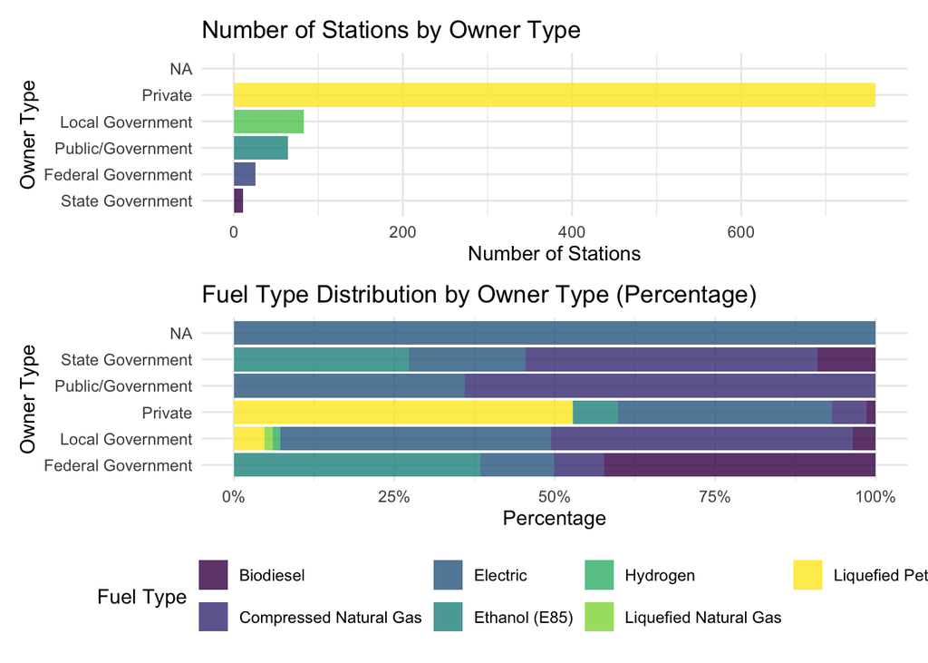

Distribution of Stations by Ownership Type

```r
# Ownership type analysis
ownership_summary <- combined_data |>
  count(owner_type_full, fuel_type_full) |>
  group_by(owner_type_full) |>
  mutate(
    owner_total = sum(n),
    percentage = n / owner_total * 100
  ) |>
  ungroup()

# Total by ownership type
owner_totals <- combined_data |>
  count(owner_type_full, sort = TRUE) |>
  mutate(owner_type_full = fct_reorder(owner_type_full, n))

# Stations by ownership type
p7 <- owner_totals |>
  ggplot(aes(x = owner_type_full, y = n, fill = owner_type_full)) +
  geom_col(alpha = 0.8) +
  coord_flip() +
  scale_fill_viridis_d(name = "Owner Type") +
  labs(
    title = "Number of Stations by Owner Type",
    x = "Owner Type",
    y = "Number of Stations"
  ) +
  theme_minimal() +
  theme(legend.position = "none")

# Fuel type distribution by ownership type
p8 <- ownership_summary |>
  ggplot(aes(x = owner_type_full, y = n, fill = fuel_type_full)) +
  geom_col(position = "fill", alpha = 0.8) +
  coord_flip() +
  scale_fill_viridis_d(name = "Fuel Type") +
  scale_y_continuous(labels = percent) +
  labs(
    title = "Fuel Type Distribution by Owner Type (Percentage)",
    x = "Owner Type",
    y = "Percentage"
  ) +
  theme_minimal() +
  theme(legend.position = "bottom")

p7 / p8
```

# Major Cities Analysis

## Top Cities by Station Count

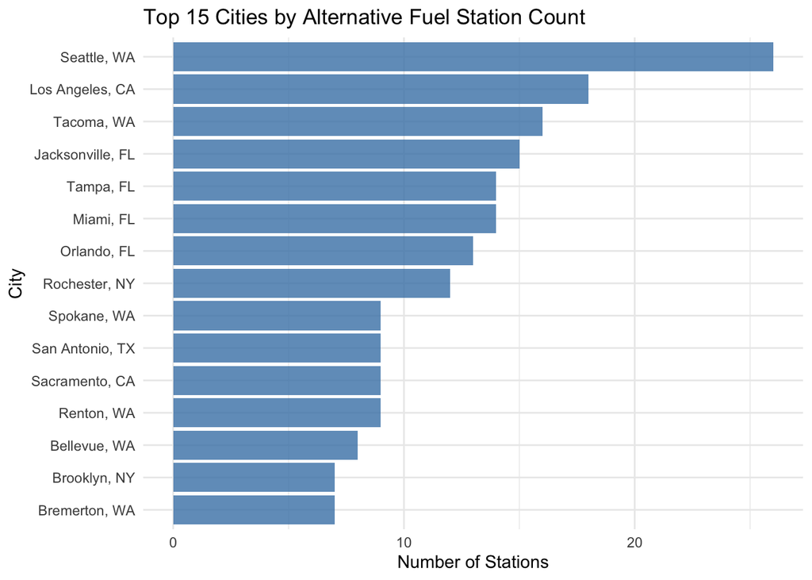

Top 15 Cities by Alternative Fuel Station Count

```r
# Top cities analysis
top_cities <- combined_data |>
  count(city, state, sort = TRUE) |>
  mutate(city_state = paste(city, state, sep = ", ")) |>
  slice_head(n = 15)

# Top cities station count
ggplot(top_cities, aes(x = fct_reorder(city_state, n), y = n)) +
  geom_col(fill = "steelblue", alpha = 0.8) +
  coord_flip() +
  labs(
    title = "Top 15 Cities by Alternative Fuel Station Count",
    x = "City",
    y = "Number of Stations"
  ) +
  theme_minimal()
```

## Fuel Type Distribution in Major Cities

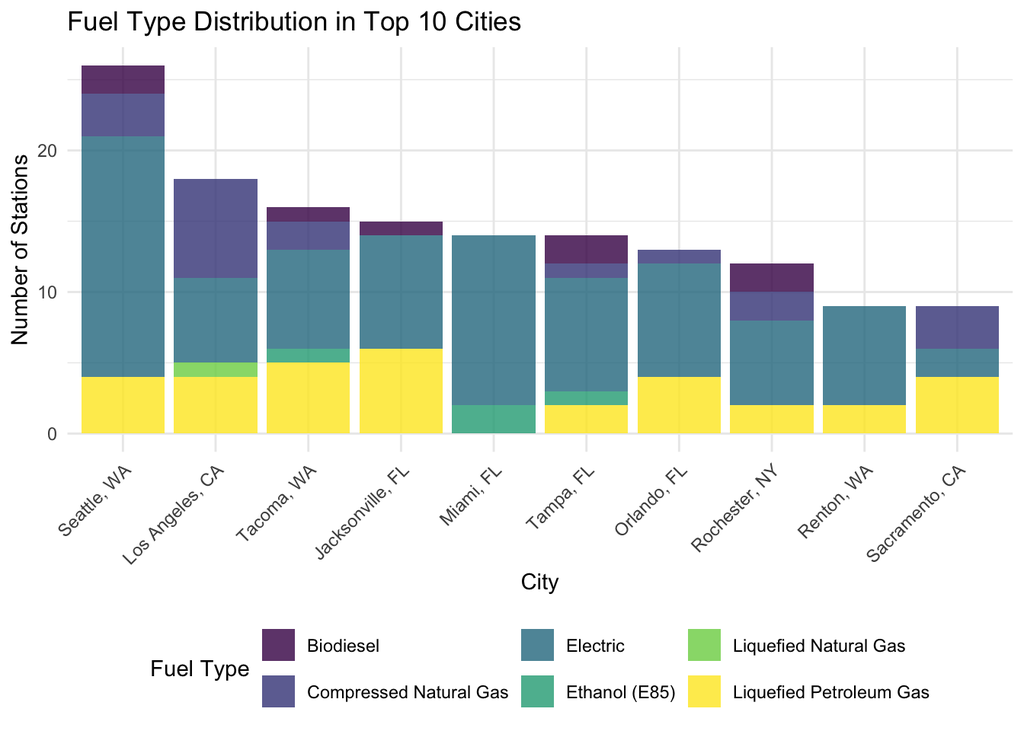

Fuel Type Distribution in Top 10 Cities

```r
# Fuel type distribution in top cities
top_cities_fuel <- combined_data |>
  mutate(city_state = paste(city, state, sep = ", ")) |>
  filter(city_state %in% top_cities$city_state) |>
  count(city_state, fuel_type_full) |>
  group_by(city_state) |>
  mutate(
    city_total = sum(n),
    percentage = n / city_total * 100
  ) |>
  ungroup()

# Top 10 cities fuel type distribution
top_10_cities <- top_cities$city_state[1:10]

top_cities_fuel |>
  filter(city_state %in% top_10_cities) |>
  ggplot(aes(x = fct_reorder(city_state, -city_total), y = n, fill = fuel_type_full)) +
  geom_col(position = "stack", alpha = 0.8) +
  scale_fill_viridis_d(name = "Fuel Type") +
  labs(
    title = "Fuel Type Distribution in Top 10 Cities",
    x = "City",
    y = "Number of Stations"
  ) +
  theme_minimal() +
  theme(
    axis.text.x = element_text(angle = 45, hjust = 1),
    legend.position = "bottom"
  )
```

# Key Insights and Conclusions

## Key Findings

```
## Key Findings:
```

```
## • Total stations: 1,000
```

```
## • Most common fuel type: Liquefied Petroleum Gas ( 40.4 %)
```

```
## • Peak installation year: 2000
```

```
## • Private ownership percentage: 75.9 %
```

## Conclusions

This analysis reveals the following important trends:

1. **Fuel Types**: Liquefied Petroleum Gas (LPG) is the most common fuel type (40.4%), followed by Electric stations (37.3%)
2. **Geographic Distribution**: All five target states have well-established alternative fuel infrastructure, with 200 stations sampled equally from each state
3. **Temporal Trends**: Installation numbers increased from the late 2000s to early 2010s
4. **Ownership Structure**: Private ownership dominates (75.9%), though public infrastructure plays an important role
5. **Geographic Patterns**: Stations tend to concentrate in major metropolitan areas, with accessibility being a key factor

These insights provide important reference information for alternative fuel infrastructure policy development and investment decisions.

**Data Source**: U.S. Department of Energy Alternative Fuel Stations API via data.gov  
**Analysis Date**: 2025-07-12  
**Analysis Tools**: R, tidyverse, ggplot2, Quarto  
**Reference**: [Using data.gov APIs in R](https://library.virginia.edu/data/articles/using-data-gov-apis-in-r) - University of Virginia Library